# Keras Test

# Installing keras

`install_keras` created a conda env that wasn’t playing nice. There seems to be an issue with the `numpy` version (see https://github.com/rstudio/keras/issues/647). As a workaround, use an older version of tensorflow:

```r
tensorflow::install_tensorflow(version = "1.12")
```

Notice the python configuration shows we’re using the `r-tensorflow` env and the `keras` module is available.

```r
reticulate::use_condaenv("r-tensorflow")
reticulate::py_config()
```

```
## python:         /Users/frank/miniconda3/envs/r-tensorflow/bin/python
## libpython:      /Users/frank/miniconda3/envs/r-tensorflow/lib/libpython3.6m.dylib
## pythonhome:     /Users/frank/miniconda3/envs/r-tensorflow:/Users/frank/miniconda3/envs/r-tensorflow
## version:        3.6.8 |Anaconda, Inc.| (default, Dec 29 2018, 19:04:46)  [GCC 4.2.1 Compatible Clang 4.0.1 (tags/RELEASE_401/final)]
## numpy:          /Users/frank/miniconda3/envs/r-tensorflow/lib/python3.6/site-packages/numpy
## numpy_version:  1.16.1
##
## python versions found:
##  /Users/frank/miniconda3/envs/r-tensorflow/bin/python
##  /usr/bin/python
##  /usr/local/bin/python3
##  /Users/frank/miniconda3/bin/python
```

```r
reticulate::py_module_available("keras")
```

```
## [1] TRUE
```

Now we’re good to go. Tutorial from https://keras.rstudio.com/articles/tutorial_basic_classification.html.

# Load data

Check out the cool destructuring operator `%<-%`!

```r
library(keras)
fashion_mnist <- dataset_fashion_mnist()
c(train_images, train_labels) %<-% fashion_mnist$train
c(test_images, test_labels) %<-% fashion_mnist$test
class_names = c('T-shirt/top',
                'Trouser',
                'Pullover',
                'Dress',
                'Coat',
                'Sandal',
                'Shirt',
                'Sneaker',
                'Bag',
                'Ankle boot')
```

# Explore data

From the tutorial:

> The following shows there are 60,000 images in the training set, with each image represented as 28 x 28 pixels. Likewise, there are 60,000 labels in the training set. Each label is an integer between 0 and 9. There are 10,000 images in the test set. Again, each image is represented as 28 x 28 pixels. And the test set contains 10,000 images labels.

```r
dim(train_images)
```

```
## [1] 60000    28    28
```

```r
dim(train_labels)
```

```
## [1] 60000
```

```r
train_labels[1:20]
```

```
##  [1] 9 0 0 3 0 2 7 2 5 5 0 9 5 5 7 9 1 0 6 4
```

```r
dim(test_images)
```

```
## [1] 10000    28    28
```

```r
dim(test_labels)
```

```
## [1] 10000
```

# Preprocess data

> The data must be preprocessed before training the network. If you inspect the first image in the training set, you will see that the pixel values fall in the range of 0 to 255.

Code slightly modified.

```r
library(tidyverse)
```

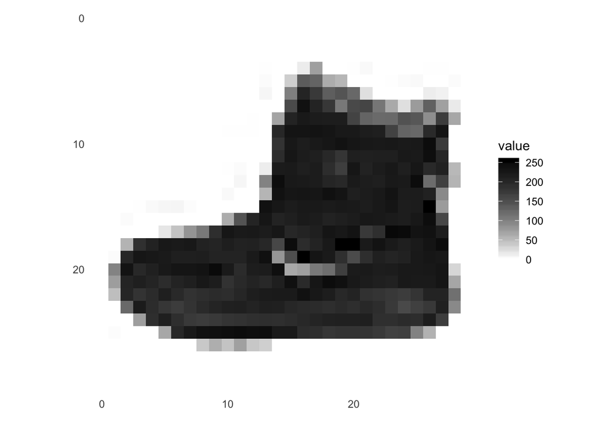

```r
image_1_mat <- train_images[1, , ]
colnames(image_1_mat) <- 1:ncol(image_1_mat)
image_1 <- as_tibble(image_1_mat) %>%
  mutate(y = row_number()) %>%
  gather(x, value, -y) %>%
  mutate(x = as.integer(x))

ggplot(image_1, aes(x = x, y = y, fill = value)) +
  geom_tile() +
  scale_fill_gradient(low = "white", high = "black", na.value = NA) +
  scale_y_reverse() +
  theme_minimal() +
  theme(panel.grid = element_blank())   +
  theme(aspect.ratio = 1) +
  labs(x = "", y = "")
```

> We scale these values to a range of 0 to 1 before feeding to the neural network model. For this, we simply divide by 255.

> It’s important that the training set and the testing set are preprocessed in the same way.

```r
train_images <- train_images / 255
test_images <- test_images / 255
```

> Display the first 25 images from the training set and display the class name below each image. Verify that the data is in the correct format and we’re ready to build and train the network.

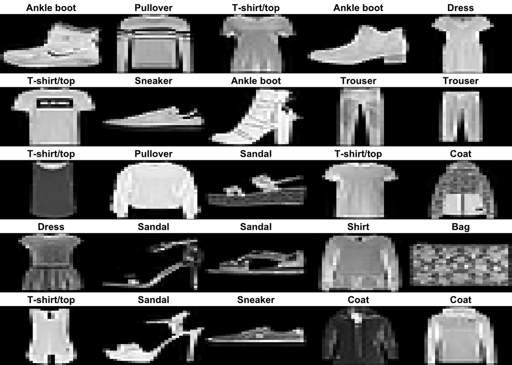

```r
par(mfcol=c(5,5))
par(mar=c(0, 0, 1.5, 0), xaxs='i', yaxs='i')
for (i in 1:25) {
  img <- train_images[i, , ]
  img <- t(apply(img, 2, rev))
  image(1:28, 1:28, img, col = gray((0:255)/255), xaxt = 'n', yaxt = 'n',
        main = paste(class_names[train_labels[i] + 1]))
}
```

# Build the model

## Set up the layers

> The basic building block of a neural network is the layer. Layers extract representations from the data fed into them. And, hopefully, these representations are more meaningful for the problem at hand.

> Most of deep learning consists of chaining together simple layers. Most layers, like layer_dense, have parameters that are learned during training.

```r
model <- keras_model_sequential()
model %>%
  layer_flatten(input_shape = c(28, 28)) %>%
  layer_dense(units = 128, activation = 'relu') %>%
  layer_dense(units = 10, activation = 'softmax')
```

> The first layer in this network, layer_flatten, transforms the format of the images from a 2d-array (of 28 by 28 pixels), to a 1d-array of 28 * 28 = 784 pixels. Think of this layer as unstacking rows of pixels in the image and lining them up. This layer has no parameters to learn; it only reformats the data.

> After the pixels are flattened, the network consists of a sequence of two dense layers. These are densely-connected, or fully-connected, neural layers. The first dense layer has 128 nodes (or neurons). The second (and last) layer is a 10-node softmax layer —this returns an array of 10 probability scores that sum to 1. Each node contains a score that indicates the probability that the current image belongs to one of the 10 digit classes.

## Compile the model

> Before the model is ready for training, it needs a few more settings. These are added during the model’s compile step: * Loss function — This measures how accurate the model is during training. We want to minimize this function to “steer” the model in the right direction. * Optimizer — This is how the model is updated based on the data it sees and its loss function. * Metrics — Used to monitor the training and testing steps. The following example uses accuracy, the fraction of the images that are correctly classified.

```r
model %>% compile(
  optimizer = 'adam',
  loss = 'sparse_categorical_crossentropy',
  metrics = c('accuracy')
)
```

## Train the model

> Training the neural network model requires the following steps: * Feed the training data to the model — in this example, the train_images and train_labels arrays. * The model learns to associate images and labels. * We ask the model to make predictions about a test set — in this example, the test_images array. We verify that the predictions match the labels from the test_labels array. To start training, call the fit method — the model is “fit” to the training data.

```r
model %>% fit(train_images, train_labels, epochs = 5)
```

> As the model trains, the loss and accuracy metrics are displayed. This model reaches an accuracy of about 0.88 (or 88%) on the training data.

## Evaluate accuracy

> Next, compare how the model performs on the test dataset.

```r
score <- model %>% evaluate(test_images, test_labels)

cat('Test loss:', score$loss, "\n")
```

```
## Test loss: 0.3413318
```

```r
cat('Test accuracy:', score$acc, "\n")
```

```
## Test accuracy: 0.877
```

> It turns out, the accuracy on the test dataset is a little less than the accuracy on the training dataset. This gap between training accuracy and test accuracy is an example of overfitting. Overfitting is when a machine learning model performs worse on new data than on their training data.

**Kind of a wonky definition of overfitting, no?**

## Make predictions

> With the model trained, we can use it to make predictions about some images.

```r
predictions <- model %>% predict(test_images)
```

> Here, the model has predicted the label for each image in the testing set. Let’s take a look at the first prediction.

```r
predictions[1, ]
```

```
##  [1] 1.197735e-06 5.991749e-09 2.252355e-09 3.132847e-09 2.459856e-07
##  [6] 8.434529e-03 2.586047e-07 5.246132e-03 1.928269e-06 9.863157e-01
```

> A prediction is an array of 10 numbers. These describe the “confidence” of the model that the image corresponds to each of the 10 different articles of clothing. We can see which label has the highest confidence value:

```r
which.max(predictions[1, ])
```

```
## [1] 10
```

> Alternatively, we can also directly get the class prediction:

```r
class_pred <- model %>% predict_classes(test_images)
class_pred[1:20]
```

```
##  [1] 9 2 1 1 6 1 4 6 5 7 4 5 7 3 4 1 2 2 8 0
```

```r
test_labels[1]
```

```
## [1] 9
```

> Let’s plot several images with their predictions. Correct prediction labels are green and incorrect prediction labels are red.

[figure not shown]

```r
par(mfcol=c(5,5))
par(mar=c(0, 0, 1.5, 0), xaxs='i', yaxs='i')
for (i in 1:25) {
  img <- test_images[i, , ]
  img <- t(apply(img, 2, rev))
  # subtract 1 as labels go from 0 to 9
  predicted_label <- which.max(predictions[i, ]) - 1
  true_label <- test_labels[i]
  if (predicted_label == true_label) {
    color <- '#008800'
  } else {
    color <- '#bb0000'
  }
  image(1:28, 1:28, img, col = gray((0:255)/255), xaxt = 'n', yaxt = 'n',
        main = paste0(class_names[predicted_label + 1], " (",
                      class_names[true_label + 1], ")"),
        col.main = color)
}
```

> Finally, use the trained model to make a prediction about a single image.

```r
# Grab an image from the test dataset
# take care to keep the batch dimension, as this is expected by the model
img <- test_images[1, , , drop = FALSE]
dim(img)
```

```
## [1]  1 28 28
```

> Now predict the image.

```r
predictions <- model %>% predict(img)
predictions
```

```
##              [,1]         [,2]         [,3]         [,4]         [,5]
## [1,] 1.197732e-06 5.991761e-09 2.252355e-09 3.132847e-09 2.459851e-07
##             [,6]         [,7]        [,8]         [,9]     [,10]
## [1,] 0.008434529 2.586042e-07 0.005246136 1.928267e-06 0.9863157
```

> `predict` returns a list of lists, one for each image in the batch of data. Grab the predictions for our (only) image in the batch.

```r
# subtract 1 as labels are 0-based
prediction <- predictions[1, ] - 1
which.max(prediction)
```

```
## [1] 10
```

> Or, directly getting the class prediction again.

```r
class_pred <- model %>% predict_classes(img)
class_pred
```

```
## [1] 9
```

> And, as before, the model predicts a label of 9.